# Flawless feature release at enterprise internet companies

John Chee

Software Engineer in San Francisco, CA | @chee1bot on Twitter

# What's the problem?

- We have a change (new feature or bugfix)
- We want every customer to have that change

[figure not shown]

# The easy solution

- Once upon a time we could do something simple
  - Our application ran on a single computer
    - Change a file
    - Restart the program
    - Worst case: restart the whole computer
- Downtime was accepted

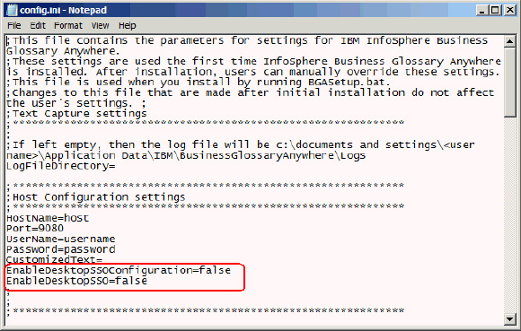

# It's not that easy anymore

- Consumer Internet companies measure downtime in dollars lost
- Customers will flee
  - From the sites that are down
  - To their competitors that are still online

# Many applications are BIG now

- Enterprise applications run on many machines (> 1 and < ???)

[figure not shown]

# The refined problem

- Deliver a feature to hundreds of millions of users
- Minimize downtime
- The application runs on 1000s of machines
- Enabling or disabling of the feature should happen instantly

# Enterprise Architecture

- Getting many computers to agree requires a well architected system
- A problem that has been studied for a while
  - Lamport, L.; Shostak, R.; Pease, M. (1982). "The Byzantine Generals Problem"
- Software engineers want an "engineer-friendly" version
  - Google has "Chubby"
    - Google Research Publication: Chubby Distributed Lock Service. research.google.com
  - Apache has "Zookeeper"
    - zookeeper.apache.org
- Failures happen in practice!

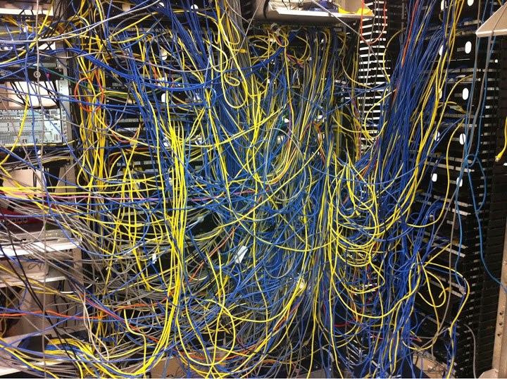

# Operational Execution Excellence

- Ideal customer impact
- The customer should only notice exactly what we want
- Ideally:
  - No additional loading time
  - No requirement to logout and login
- At first we only want a fraction of users to experience the change
  - Over time we want more and more users to experience the change
  - If there's a problem we need to instantly disable the change